# Classical Decomposition of Time Series Data

## Introduction

The purpose of this R Notebook file is to understand the classical decomposition of time series data. Here, we will manually decompose **an additive** time series data.

## Data

We will be using the `elecequip` data for this analysis.

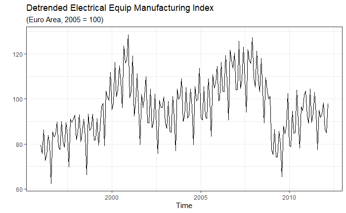

```r
autoplot(elecequip) +
  labs(title = "Detrended Electrical Equip Manufacturing Index",
       subtitle = "(Euro Area, 2005 = 100)", y = "")
```

## Procedure for decomposing the series

### Step 1: Detect the trend using a centered Moving Average

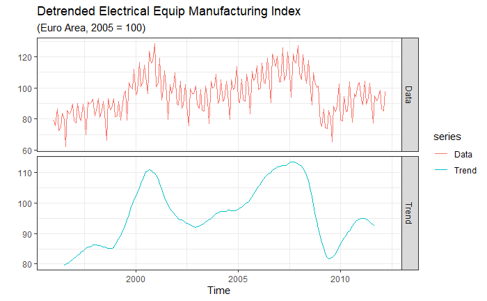

```r
elec.trend <- ma(elecequip, order = 12, centre = TRUE)
cbind("Data" = elecequip,"Trend" = elec.trend) %>%
  autoplot(facets = TRUE, colour = TRUE) +
  labs(title = "Detrended Electrical Equip Manufacturing Index",
       subtitle = "(Euro Area, 2005 = 100)", y = "")
```

```r
Tt <- elec.trend # Will use the trend from this model
```

#### What about other Trend methods?

```r
low1 <-  lowess(elecequip,f=2/3)
low2 <-  lowess(elecequip,f=1/3)
low3 <-  lowess(elecequip,f=0.1)

elecequip %>% plot(main = "Detrended Electrical Equip Manufacturing Index",
       sub = "(Euro Area, 2005 = 100)", ylab = "")
lines(low1, lty = 2, lwd = 3, col = "red")
```

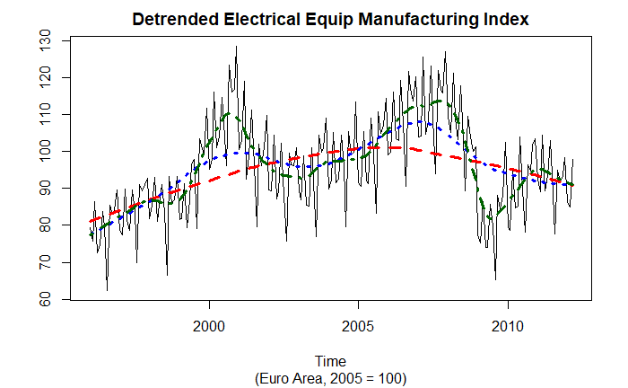

```r
lines(low2, lty = 3, lwd = 3, col = "blue")
lines(low3, lty = 4, lwd = 3, col = "darkgreen")
```

### Step 2: Detrend the Series

*Detrending* the series means that we are removing the underlying long-term pattern in the data.

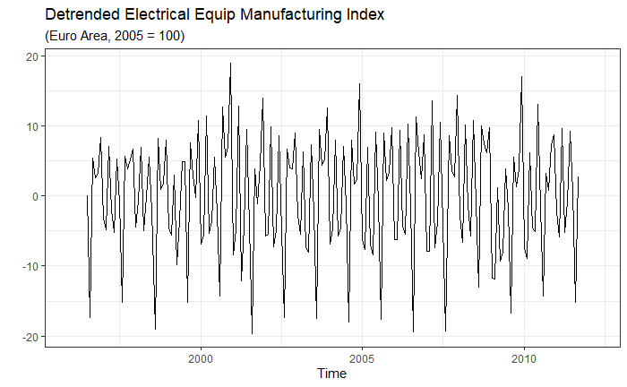

```r
elec_detrend <- elecequip- elec.trend
autoplot(elec_detrend) +
  labs(title = "Detrended Electrical Equip Manufacturing Index",
       subtitle = "(Euro Area, 2005 = 100)", y = "")
```

### Step 3: Get the average seasonality across the `seasons`.

The classical decomposition assumes that the seasonal component will repeat itself across the length of the series. The classical decomposition does not allow for the seasonal component to differ across time. Looking at the `elec` data, you can quickly see how this assumption could be violated.

1. Drop NA’s and get the seasonal averages using a loop. The subset function will come in handy here.

```r
#Extract the frequency of the data
ff <- frequency(elec_detrend)

avg <- NULL # Create a empty variable that will hold our monthly averages.

for (i in 1:ff){
avg[i] <- mean(subset(elec_detrend,month = i),na.rm = TRUE)
}
# avg

## subtract mean to make overall mean = 0
avg.seas <- avg - mean(avg)
avg.seas
```

```
 [1]  -5.887662  -6.199273   8.083171  -6.314968  -4.818468
 [6]   7.976088  -1.575338 -16.870416   7.304324   3.007671
[11]   3.847366  11.447504
```

*Before we proceed to the next step of creating the entire time series of seasonal effects, let’s plot them for each month to see what is happening within a year:*

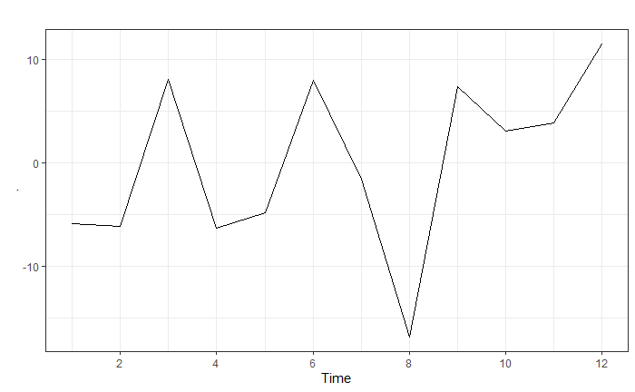

```r
avg.seas %>% ts() %>% autoplot()
```

2. Replicate the Averages to match the number of years of the original data

```r
# Extract the length of the data
ll <- length(elecequip)

# Get the number of periods (think years)in the original dataset.

periods <- ll%/%ff  # %/% Will perform integer division.

elec.seas <- ts(rep(avg.seas,periods + 1)[seq(ll)],
                start=c(1956,1), frequency = 12)
```

3. Recall that we lost the first and last 6 observations due to the centered MA so we will set them to `NA`s.

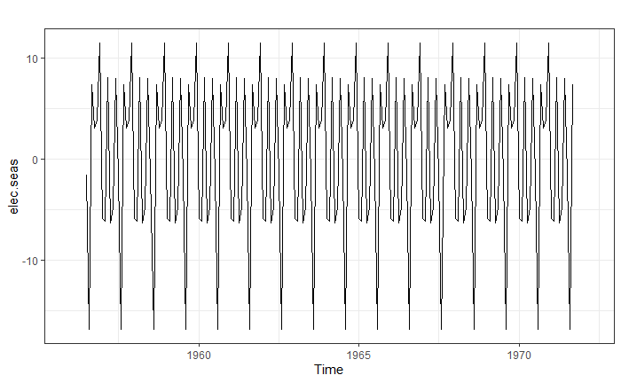

```r
elec.seas[1:6] <- NA -> elec.seas[(ll-5):ll]
# Notice that I am able to assign the NA to two things at once
autoplot(elec.seas)
```

### Step 3: Alternative approach using Regressions

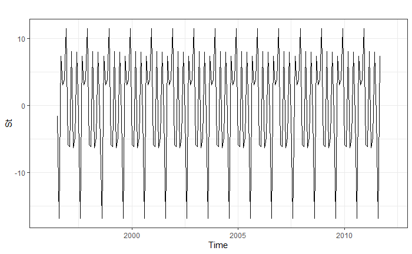

```r
elec.seas.reg <- tslm(elec_detrend ~ season)
St <- fitted(elec.seas.reg)
autoplot(St)
```

### Step 4: Get the remainder Component

We can achieve this by manipulating the identity below:

$$\begin{align}
Y_t & = S_t + T_t + R_t\\
\Rightarrow R_t &= Y_t - S_t - T_t
\end{align}$$

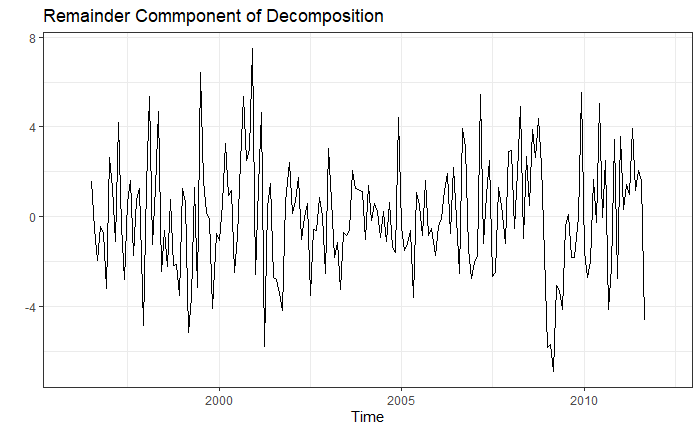

```r
# Using the regression model results
Rt <- elecequip - Tt - St

Rt %>% autoplot() +
  labs(title = "Remainder Commponent of Decomposition", y = "")
```

### Did we do it right?

At first glance the exercise may seem tedious and potentially confusing, but it demonstrates the additive decomposition of a time series from the notes, $y_t = S_t + T_t + R_t$. We will check this below.

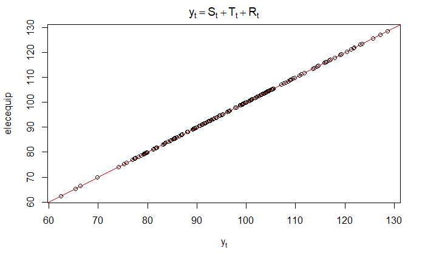

```r
yt <- Tt + St + Rt
plot(x = yt, y = elecequip , type = "p",
     main = bquote(y[t] == S[t] + T[t] + R[t]),
     xlab = bquote(y[t]))
abline(0,1, lwd = 1, col = "red")
```

## Decomposition

Now that we have all three (3) components of the decomposition, we can plot them all together. We will also compare the results against `R`’s `decompose` function.

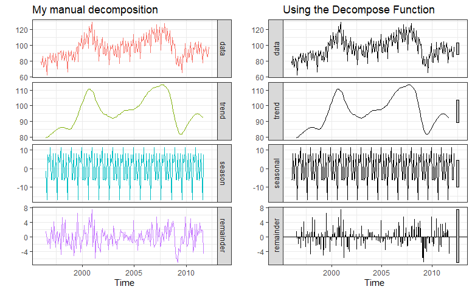

```r
# Manually:
g1 <- cbind("data" = elecequip,
            "trend" = Tt,
            "season" = St,
            "remainder" = Rt) %>%
  autoplot(facets = TRUE, colour = TRUE) +
  theme(legend.position = 'none') +
  labs(title = "My manual decomposition",y = "")
# Using the Package:
g2 <- elecequip%>% decompose(type = "additive") %>%
  autoplot()+ ggtitle("Using the Decompose Function")
gridExtra::grid.arrange(g1,g2, ncol=2)
```